# Racial Inequalities in the Prison System

Sanjana Somayajula

2022-11-22

## Abstract

In this report, we analyzed the trends in incarceration across the United States. I decided to focus on how race plays a role in incarceration, in order to identify any disproportionalities and general inequalities. I also focused much of my data on California, my home state, as is a very racially diverse state.

## Introduction

The main goal of this data analysis is to expose patterns of inequality using incarceration data presented by *Vera*, a national organization that partners with impacted communities and government leaders for change. The social issues related to this data set have to do with racial inequalities in the prison system, as well as discrepancies with gender. A direct stakeholder in this research could be anyone who is planning to report on inequalities and demographics within the prison system, and an indirect stakeholder could be the general public, as this data impacts everyone due to the fact that anyone could be at risk of incarceration and should be aware of inequalities faced by certain minorities. The central value is information availability as Vera presents information that is often hard to understand and find. The main question I answer in this report is: What role does race play in incarceration? More specifically: Where in the United States is the Black population more likely to be incarcerated?

## Growth of the U.S. Prison Population

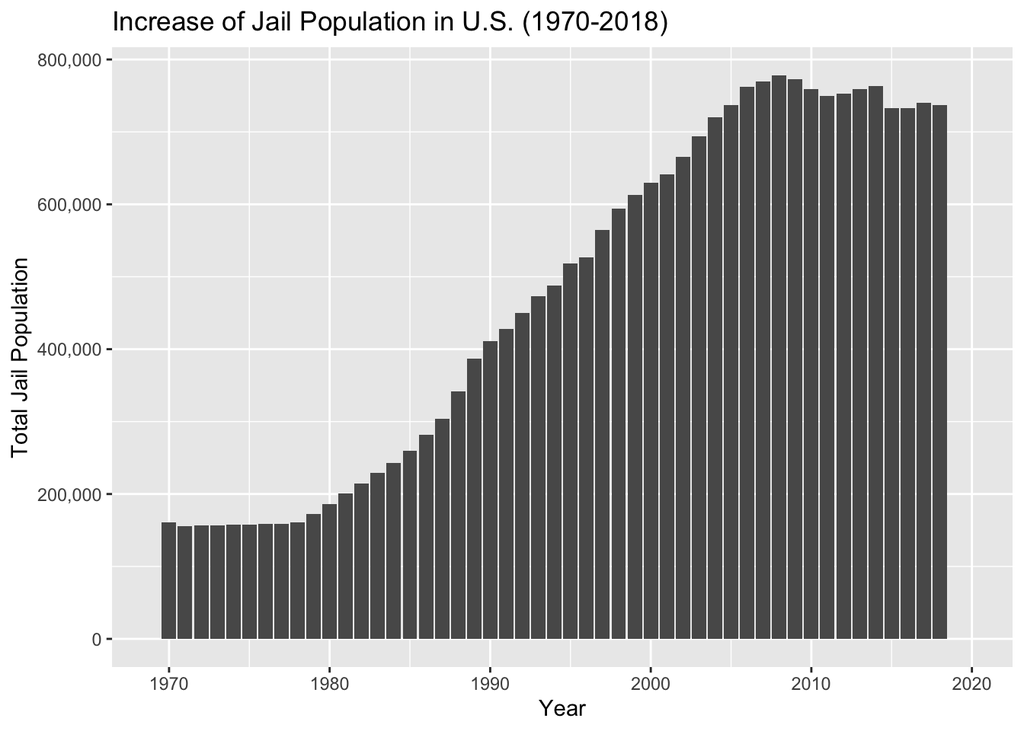

*Caption: This is a bar chart that shows the growth of the U.S. prison population from 1970 to 2018.*

The data shows a general increase of incarceration rates in the United States. The rate hit its peak around 2010, and comes back down again, though not significantly. My main question is: What caused such an increase in total incarceration? Is it due to an increase in policing or an increase in crime?

## Growth of Prison Population by State

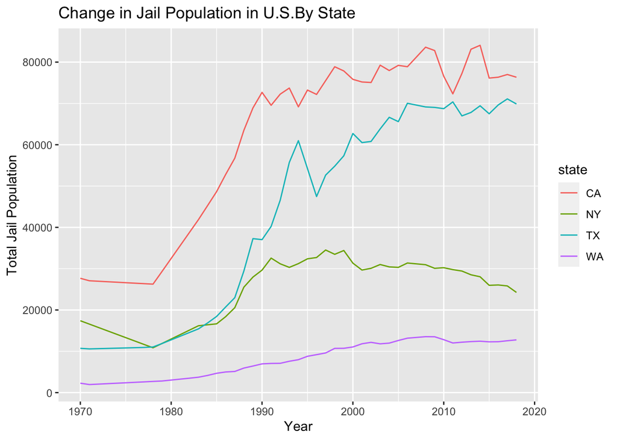

*Caption: This is a line chart that shows the growth of the U.S. prison population from 1970 to 2018 by one or more states.*

## Change in Percentage of Incarcerated Population by Race Over Time?

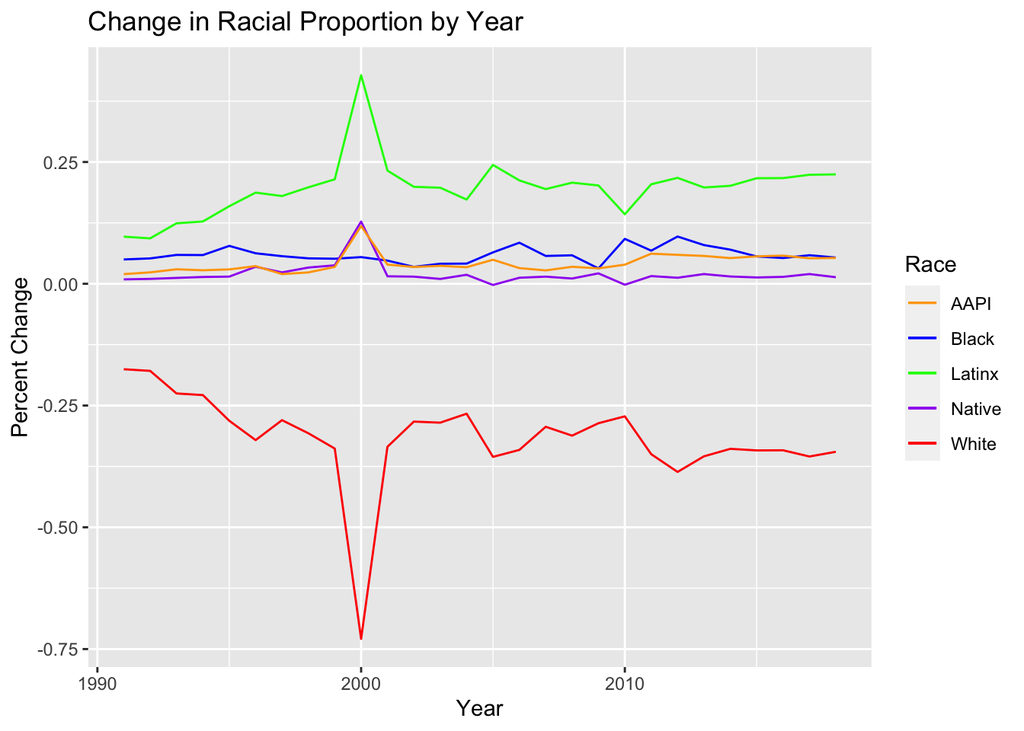

*Caption: This is a line chart showing the change in percentage of incarcerated population by each racial group. The blue line references the black population, the red represents the white population, the green represents the Latinx population, and the purple represents the native population, and the orange represents the AAPI population.*

## What was the United States Black Jail Population in 2018?

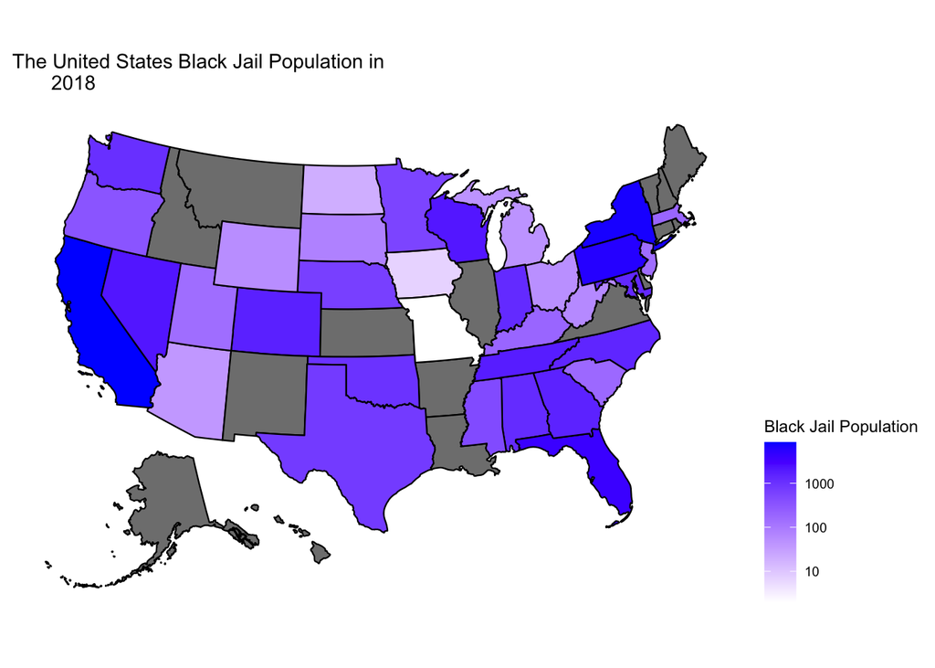

*Caption: This is a US chart meant to compare and contrast the total Black incarcerated population for each state in 2018.*

This chart represents all of the Black incarcerated population by each state. The darker the shade of blue, the higher the population. The gray areas mean that there was no information available for that state. I chose 2018 because it was the most recent data. As can be examined from the chart, the highest total Black jail population is in California and New York. These states have the largest black population so that makes sense. Excluding California and New York, southern states tend to have higher incarceration rates, which also aligns, as these states have a larger history of racism. This presents an example of inequality as, due to overpolicing in larger cities such as in Los Angeles, and New York City, there is a much larger rate of incarceration. My question is: Is there also a similar pattern of incarceration for other racial groups? And what is this pattern? Also, what inequalities would this examination of data unearth?